# Weekly 7: Who Visits the National Parks?

Author

Chris Murphy

## Overview

In class, we started from a default chart and asked one question about every change: **what does this choice make the reader see?**

This week you’ll make those decisions yourself, on new data: visits to the U.S. National Parks, from the National Park Service, as collected for TidyTuesday. Kentucky has one of the parks in the data: Mammoth Cave.

The question: **Where does Mammoth Cave sit among the National Parks?**

This weekly is about **visualization judgment**. You’ll do a little cleaning to get there, but the point is the charts and your reasons for them.

A few things:

1. Add `#| echo: false` to your code blocks.
2. Use a new block when you move to a new task.
3. Code goes in the blocks. **Answers go outside them**, as prose. A comment inside a code chunk is not an answer.
4. Save the raw data to a file **once**, then work from the file. After it’s saved, add `#| eval: false` to the block that downloads it.
5. Every chart you hand in should use a colorblind-safe palette, if it uses color at all.

Due Monday, November 9 at 8pm.

# Part 1: Get the data, and know what you’re plotting

The data is here:

`https://raw.githubusercontent.com/rfordatascience/tidytuesday/master/data/2019/2019-09-17/national_parks.csv`

Read it in and save a copy to `data/raw/national_parks.csv`. Then read your saved copy and call it `parks_raw`.

```
# A tibble: 21,560 × 1
   year
   <chr>
 1 1904
 2 1941
 3 1961
 4 1935
 5 1982
 6 1919
 7 1969
 8 1967
 9 1944
10 1989
# ℹ 21,550 more rows
```

> What type is `year`? Why isn’t it numeric? it is chr. The original file has entries titled total.

```
[1] 30
```

> Why would leaving the `Total` rows in create a problem for an analysis of annual visitation? Summarizes visits amongst years rather than a single year.

> How many kinds of `unit_type` are there? For this assignment, keep only `National Park` records and annual observations. Call the result `np`, and make `year` a number. there are 30

```
# A tibble: 30 × 2
   unit_type                    n
   <chr>                    <int>
 1 National Monument         5051
 2 National Park             4743
 3 National Historic Site    3274
 4 National Historical Park  1984
 5 National Memorial         1486
 6 National Battlefield       859
 7 National Recreation Area   806
 8 National Military Park     613
 9 National Preserve          559
10 National Seashore          494
# ℹ 20 more rows
```

> Before we visualize anything, check whether one row is one park in one year.

```
# A tibble: 95 × 3
   unit_code  year records
   <chr>     <int>   <int>
 1 DENA       1922       2
 2 DENA       1923       2
 3 DENA       1924       2
 4 DENA       1925       2
 5 DENA       1926       2
 6 DENA       1927       2
 7 DENA       1928       2
 8 DENA       1929       2
 9 DENA       1930       2
10 DENA       1931       2
# ℹ 85 more rows
```

You should find one park that appears twice in the same year. Here’s the cleaning decision for it; run this:

```
[1] 60
```

```
[1] 1904
```

```
[1] 2016
```

> After that cleaning, what does one row represent? How many parks are represented? What years does the file cover? 60 parks are represented. The file covers 1904-2016

> Why does the ending year matter for the claims you make later? Because the last date covered is 10 years old, so not current.

# Part 2: Start with the obvious chart

Your audience wants to know how the National Parks compared in 2016.

> Make the most obvious bar chart: park on the x-axis and 2016 visitors on the y-axis. Don’t improve it yet.

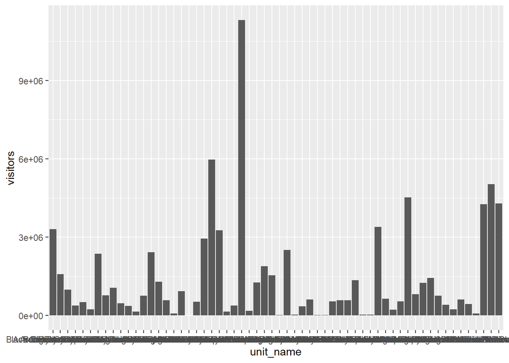

> Is the chart technically correct? What makes it difficult to use? Yes. It is a lot of parks put onto a small graph making the scale visually disgusting and the names of the parks impossible to read.

# Part 3: Make the comparison readable

> Revise the chart so the park names are readable and the ordering helps the reader compare visitation.

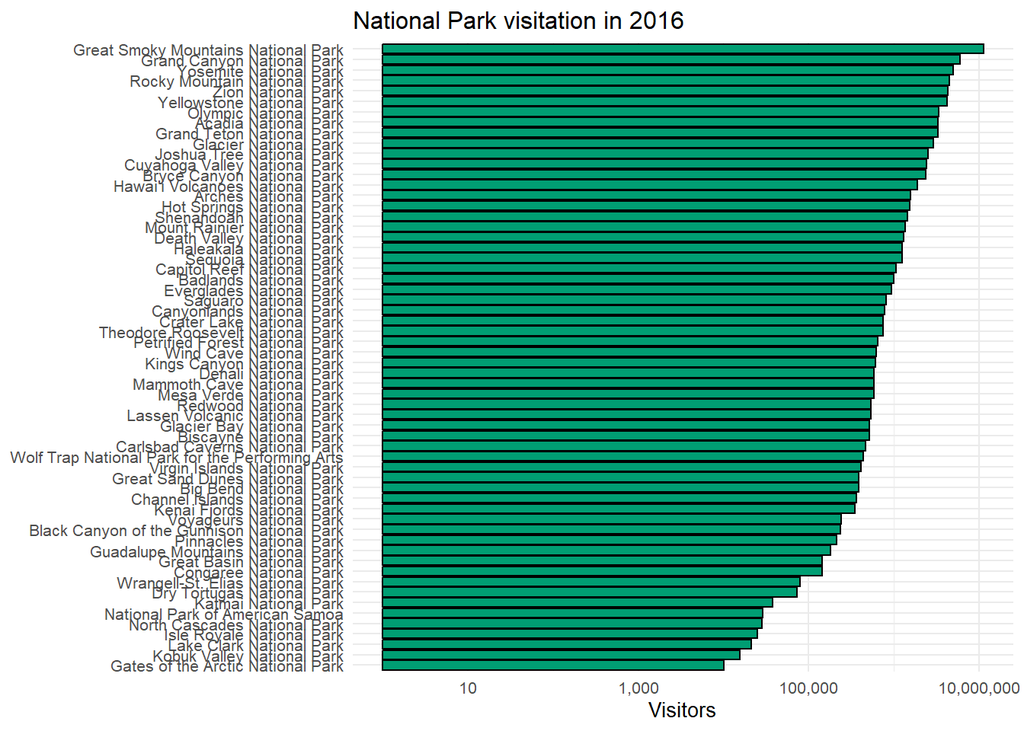

> Why put park names on the y-axis instead of the x-axis? Makes it possible to read the names (why not flip the names on the x axis to just read vertically rather than horizontally)

> Why reorder the parks by visitors? makes it easier to read and prettier

> Should every park get its own color? not when there are this many parks

# Part 4: A real visualization problem

Mammoth Cave is the local park we care about. First, find where it ranks in 2016.

```
# A tibble: 1 × 4
  unit_name                   year visitors  rank
  <chr>                      <int>    <dbl> <int>
1 Mammoth Cave National Park  2016   586514    33
```

Now the design problem:

> A chart of only the top 10 parks makes Mammoth Cave disappear. A chart with 60 equally emphasized parks makes the reader work too hard. Create one visualization that helps a reader understand where Mammoth Cave sits relative to the other National Parks.

There is no one right chart here. Make the one you can defend.

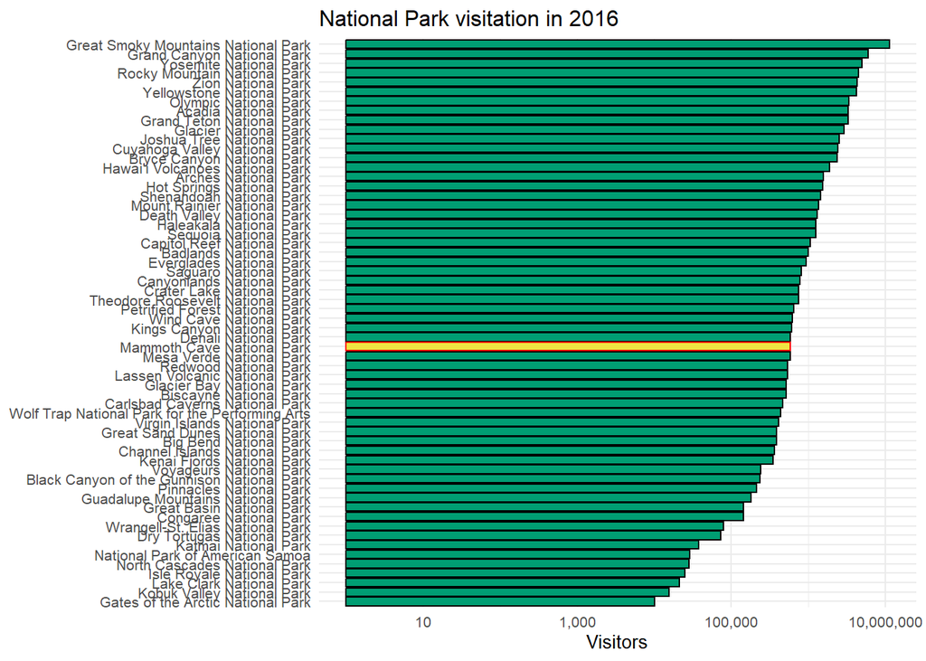

# Part 5: Defend the choices

> What should the reader notice first when they look at your final chart? Where mammoth cave is.

> Name two visualization choices you made deliberately. For each one, explain what that choice helps the reader see. I changed the color and fill of mammoth cave to make it very obvious that I am trying to specifically bring attention to it by standing out from the rest of the parks.

> Name one visualization choice you considered but rejected. Why did you reject it? I originally just did fill and not color but changed it because i wanted to make it easier to determine the seperation.

> What does your chart support saying? What does it **not** support saying? That mammoth cave falls in the middle of the pack for visitation amongst all of the national parks. It does not support mammoth cave being the most popular or even getting visitation close to the top.

# Bringing it together

> In 3–4 sentences, answer the question for your reader: where does Mammoth Cave sit among the National Parks? Include one number, one interpretation, and one limitation.

> In 2016, Mammoth Cave recorded 586,514 visits and ranked 33 out of 60 National Parks in this dataset. This places it the less visited half of the parks shown. The comparison makes its position clear without excluding less-visited parks. However, the data describe 2016 only and do not show whether Mammoth Cave holds the same position today.

# Disclosure appendix

> What did you try first? Include the code you wrote and the actual error message, or a clear description of the problem if there was no error.

> If you used an AI system: the exact prompt, exactly what it returned, what it got wrong or left unclear, and what you changed.

> If you didn’t use one, say so.

I did not know how to read the csv using the link so i asked chat gpt the following:

“using tidyverse how do i read in”[https://raw.githubusercontent.com/rfordatascience/tidytuesday/master/data/2019/2019-09-17/national_parks.csv”](https://raw.githubusercontent.com/rfordatascience/tidytuesday/master/data/2019/2019-09-17/national_parks.csv%22)”

and it responded:

“library(tidyverse)

dir.create(“data/raw”, recursive = TRUE, showWarnings = FALSE)

parks_download <- read_csv( “[https://raw.githubusercontent.com/rfordatascience/tidytuesday/master/data/2019/2019-09-17/national_parks.csv”](https://raw.githubusercontent.com/rfordatascience/tidytuesday/master/data/2019/2019-09-17/national_parks.csv%22) )

write_csv(parks_download, “data/raw/national_parks.csv”)

parks_raw <- read_csv(“data/raw/national_parks.csv”)”

once it gave me that I edited it to be:

parks <- read_csv(“[https://raw.githubusercontent.com/rfordatascience/tidytuesday/master/data/2019/2019-09-17/national_parks.csv”)](https://raw.githubusercontent.com/rfordatascience/tidytuesday/master/data/2019/2019-09-17/national_parks.csv%22))

write_csv(parks, “data/raw/national_parks.csv”)

parks_raw <- read_csv(“data/raw/national_parks.csv”)

# Before you submit

Render in a clean session: restart R, then render. Commit and push the `.qmd`, the `.html`, **and** your saved `.csv`.